# d83ccfb7-2536-4a1f-b3bd-c84b51cb1ccb

### Предобработка данных

```python
# посмотрим сколько пустых значений в названии населённого пункта
print(len(data[data['locality_name'].isna()]), ' из ', data.shape[0], round(len(data[data['locality_name'].isna()]) / data.shape[0],4))
```

```
49  из  23699 0.0021
```

Т.к. данных с отсутствующим населенным пунктом очень мало, а населённый пункт очень важен для исследования, считаю, что эти данные лучше отсечь.

```python
#удаление строк, в столбцах которых locality_name = NaN
data = data.dropna(subset=['locality_name'])
data.shape[0]
```

```
23650
```

<div class="alert alert-success"; style="border-left: 7px solid green"> **👍 Комментарий ревьюера**

Молодец, что используешь метод dropna, а также пишешь, какую часть датасета ты удаляешь – это помогает не перефильтровать данные </div>

Определяю категории населённых пунктов

```python
def categorize_locality(row):
    try:
        if 'поселок' in row:
            return 'поселок'
        elif 'село' in row:
            return 'село'
        elif 'деревня' in row:
            return 'деревня'
        elif 'товарищество' in row:
            return 'товарищество'
        elif 'Пансионат' in row:
            return 'пансионат'
        else:
            return 'город'
    except:
        return 'город'

data = data.apply(lambda x: x.replace({'ё':'е'}, regex=True))
data['locality_type'] = data['locality_name'].apply(categorize_locality)

#data.info()
```

Считаю, что если нет данных о количестве дней в продаже, значит недвижимость не была продана и эти данные лучше не брать для анализа

<div class="alert alert-success"; style="border-left: 7px solid green"> **👍 Комментарий ревьюера**

Согласна </div>

```python
#удаление строк, в столбцах которых days_exposition = NaN
data = data.dropna(subset=['days_exposition'])
data.shape[0]
```

```
20470
```

```python
#посмотрим сколько данных без пропусков
best_data = data.dropna()
best_data.shape[0]
```

```
250
```

Предполагаю, что населённых пунктов с одинаковыми именами в пределах области нет. Префикс перед именем лучше убрать

```python
data = data.apply(lambda x: x.replace({'поселок при железнодорожной станции ':''}, regex=True))
data = data.apply(lambda x: x.replace({'поселок городского типа имени ':''}, regex=True))
data = data.apply(lambda x: x.replace({'поселок городского типа ':''}, regex=True))
data = data.apply(lambda x: x.replace({'городской поселок ':''}, regex=True))
data = data.apply(lambda x: x.replace({'поселок при железнодорожной станции ':''}, regex=True))
data = data.apply(lambda x: x.replace({'коттеджный поселок ':''}, regex=True))
data = data.apply(lambda x: x.replace({'поселок станции ':''}, regex=True))
data = data.apply(lambda x: x.replace({'поселок ':''}, regex=True))
data = data.apply(lambda x: x.replace({'село ':''}, regex=True))
data = data.apply(lambda x: x.replace({'деревня ':''}, regex=True))
data = data.apply(lambda x: x.replace({'садовое товарищество ':''}, regex=True))
data = data.apply(lambda x: x.replace({'садоводческое некоммерческое товарищество ':''}, regex=True))
data = data.apply(lambda x: x.replace({'садовое товарищество ':''}, regex=True))
data = data.apply(lambda x: x.replace({'Пансионат ':''}, regex=True))
# и проверяю дубликаты
data.duplicated().sum()
```

```
0
```

```python
data['locality_name'].value_counts().head(13)
```

```
Санкт-Петербург    13638
Мурино               551
Кудрово              441
Шушары               408
Всеволожск           339
Колпино              308
Пушкин               307
Парголово            302
Гатчина              268
Выборг               208
Петергоф             176
Сестрорецк           163
Красное Село         158
Name: locality_name, dtype: int64
```

Заполним 'is_apartment' как False, т.к. апартаменты достаточно редкое явление.

```python
data.groupby('is_apartment')['is_apartment'].count()
data['is_apartment'] = data['is_apartment'].fillna(False)

# Код добавлен после ревью
data['is_apartment'] = data['is_apartment'].astype('bool')
```

<div class="alert alert-success"; style="border-left: 7px solid green"> **👍 Комментарий ревьюера**

Да, я бы сделала так же </div>

Количество балконов на "0", если количество не указано.

```python
data['balcony'] = data['balcony'].fillna(0)
```

Заменю расстояние до центра в значение в километрах для удобства группировки и заполню пропуски. Отсутствующие значения заменю на -1.

```python
data['cityCenters_nearest'] = data['cityCenters_nearest'].fillna(-1000)

data['cityCenters_nearest'] = round(data['cityCenters_nearest'] / 1000, 0).astype('int')

data['cityCenters_nearest'].sample(3)

#data.info()
```

```
406      14
702       9
22138    -1
Name: cityCenters_nearest, dtype: int64
```

<div class="alert alert-success"; style="border-left: 7px solid green"> **👍 Комментарий ревьюера**

И можно было бы сразу перевести данные в int, раз мы их округлили до целочисленных </div>

**Комментарии для ревьюера:** Перевести эти данные я пыталась. В поле cityCenters_nearest много пропусков. Которые определяются как тип float. Перевести эти данные методами astype или int() не получилось, поэтому оставила как есть. Подскажи пожалуйста как справиться с этими данными? Буду очень благодарна.

<div class="alert alert-success"; style="border-left: 7px solid green"> **👍 Комментарий ревьюера 2**

Не получалось перевести из-за пропусков. Есть два основных способа работы с пропусками: оставить как есть или заполнить чем-то. Заполнить можно вычисленными данными (средние/медианы и тп), а можно значением-заглушкой. Например, -1. Так ты не перепутаешь из с реальными значениями и сэкономишь память </div>

Недостающие значения высоты потолков беру как медианное значение по типу населённого пункта.

```python
for t in data['locality_type'].unique():
    q = data.loc[(data['locality_type'] == t), 'ceiling_height'].median()
    data.loc[(data['locality_type'] == t) & (data['ceiling_height'].isna()), 'ceiling_height'] = q
    display(q)
```

```
2.6
```

```
2.65
```

```
2.7
```

```
2.55
```

```
2.6
```

<div class="alert alert-warning"; style="border-left: 7px solid gold"> **💡 Комментарий ревьюера**

А вот тут кажется слишком грубым округлением: в городе Санкт-Петербург есть старинные дома с высокими потолками, хрущевки и современные новостройки. Высота потолков больше зависит от типа дома, нежели от населенного пункта

</div>

```python
len(data['ceiling_height'])
```

```
20470
```

Если высота потолков указана более 24 метров, уменьшаю её в 10 раз, т.к. это похоже на ошибку

```python
rows = data['ceiling_height'] > 24

data.loc[rows, 'ceiling_height'] = data.loc[rows, 'ceiling_height'] / 10

data[rows]
```

|  | total_images | last_price | total_area | first_day_exposition | rooms | ceiling_height | floors_total | living_area | floor | is_apartment | ... | balcony | locality_name | airports_nearest | cityCenters_nearest | parks_around3000 | parks_nearest | ponds_around3000 | ponds_nearest | days_exposition | locality_type |
| --- | --- | --- | --- | --- | --- | --- | --- | --- | --- | --- | --- | --- | --- | --- | --- | --- | --- | --- | --- | --- | --- |
| 355 | 17 | 3600000.0 | 55.2 | 2018-07-12T00:00:00 | 2 | 2.50 | 5.0 | 32.0 | 2 | False | ... | 2.0 | Гатчина | NaN | -1 | NaN | NaN | NaN | NaN | 259.0 | город |
| 4643 | 0 | 4300000.0 | 45.0 | 2018-02-01T00:00:00 | 2 | 2.50 | 9.0 | 30.0 | 2 | False | ... | 1.0 | Санкт-Петербург | 12016.0 | 13 | 1.0 | 658.0 | 1.0 | 331.0 | 181.0 | город |
| 4876 | 7 | 3000000.0 | 25.0 | 2017-09-27T00:00:00 | 0 | 2.70 | 25.0 | 17.0 | 17 | False | ... | 2.0 | Мурино | NaN | -1 | NaN | NaN | NaN | NaN | 28.0 | поселок |
| 5246 | 0 | 2500000.0 | 54.0 | 2017-10-13T00:00:00 | 2 | 2.70 | 5.0 | 30.0 | 3 | False | ... | 2.0 | Мины | NaN | -1 | NaN | NaN | NaN | NaN | 540.0 | деревня |
| 5669 | 4 | 4400000.0 | 50.0 | 2017-08-08T00:00:00 | 2 | 2.60 | 9.0 | 21.3 | 3 | False | ... | 2.0 | Санкт-Петербург | 28981.0 | 11 | 1.0 | 305.0 | 0.0 | NaN | 267.0 | город |
| 5807 | 17 | 8150000.0 | 80.0 | 2019-01-09T00:00:00 | 2 | 2.70 | 36.0 | 41.0 | 13 | False | ... | 5.0 | Санкт-Петербург | 18732.0 | 20 | 0.0 | NaN | 3.0 | 80.0 | 38.0 | город |
| 10773 | 8 | 3800000.0 | 58.0 | 2017-10-13T00:00:00 | 2 | 2.70 | 10.0 | 30.1 | 3 | False | ... | 2.0 | Мурино | NaN | -1 | NaN | NaN | NaN | NaN | 71.0 | поселок |
| 11285 | 0 | 1950000.0 | 37.0 | 2019-03-20T00:00:00 | 1 | 2.50 | 5.0 | 17.0 | 4 | False | ... | 2.0 | Луга | NaN | -1 | NaN | NaN | NaN | NaN | 18.0 | город |
| 14382 | 9 | 1700000.0 | 35.0 | 2015-12-04T00:00:00 | 1 | 2.50 | 5.0 | 20.0 | 2 | False | ... | 1.0 | Новый Свет | NaN | -1 | NaN | NaN | NaN | NaN | 206.0 | поселок |
| 17857 | 1 | 3900000.0 | 56.0 | 2017-12-22T00:00:00 | 3 | 2.70 | 5.0 | 33.0 | 4 | False | ... | 0.0 | Санкт-Петербург | 41030.0 | 16 | 0.0 | NaN | 0.0 | NaN | 73.0 | город |
| 18545 | 6 | 3750000.0 | 43.0 | 2019-03-18T00:00:00 | 2 | 2.50 | 5.0 | 29.0 | 3 | False | ... | 0.0 | Санкт-Петербург | 27054.0 | 8 | 1.0 | 540.0 | 0.0 | NaN | 12.0 | город |
| 20478 | 11 | 8000000.0 | 45.0 | 2017-07-18T00:00:00 | 1 | 2.70 | 4.0 | 22.0 | 2 | False | ... | 1.0 | Санкт-Петербург | 18975.0 | 3 | 0.0 | NaN | 3.0 | 449.0 | 429.0 | город |
| 21377 | 19 | 4900000.0 | 42.0 | 2017-04-18T00:00:00 | 1 | 2.75 | 24.0 | 37.7 | 19 | False | ... | 2.0 | Санкт-Петербург | 42742.0 | 10 | 0.0 | NaN | 0.0 | NaN | 61.0 | город |
| 22869 | 0 | 15000000.0 | 25.0 | 2018-07-25T00:00:00 | 1 | 10.00 | 5.0 | 14.0 | 5 | True | ... | 5.0 | Санкт-Петербург | 34963.0 | 8 | 1.0 | 223.0 | 3.0 | 30.0 | 19.0 | город |
| 22938 | 14 | 4000000.0 | 98.0 | 2018-03-15T00:00:00 | 4 | 2.70 | 2.0 | 73.0 | 2 | True | ... | 1.0 | Нижняя | NaN | -1 | NaN | NaN | NaN | NaN | 27.0 | деревня |

15 rows × 23 columns

<div class="alert alert-success"; style="border-left: 7px solid green"> **👍 Комментарий ревьюера**

Молодец, что заметила </div>

Считаю, что высота потолков менее 2 метров и более 10 это ошибка. Таких данных не много, всего 7 записей. Их лучше убрать из анализа.

```python
data = data.loc[(data['ceiling_height'] >= 2) & (data['ceiling_height'] <= 10)]
data.shape
```

```
(20463, 23)
```

**Мои комментарии:** Заполнение пропусков с этажностью дома, если известно на каком этаже расположена квартира. Предполагаю взять 7 наиболее распространённых этажностей и округлять до ближайшего.

```python
def categorize_floor(floor):
    try:
        if floor == 1:
            return 1
        elif 1 <= floor <= 5:
            return 5
        elif 6 <= floor <= 12:
            return 12
        elif 13 <= floor <= 17:
            return 17
        elif 18 <= floor <= 25:
            return 25
        elif 26 <= floor <= 33:
            return 33
        elif 34 <= floor <= 50:
            return 50
        elif floor > 50:
            return 100
    except:
        pass

rows = data['floors_total'].isna()
data.loc[rows, 'floors_total'] = data.loc[rows, 'floor'].apply(categorize_floor)
data[rows]
```

|  | total_images | last_price | total_area | first_day_exposition | rooms | ceiling_height | floors_total | living_area | floor | is_apartment | ... | balcony | locality_name | airports_nearest | cityCenters_nearest | parks_around3000 | parks_nearest | ponds_around3000 | ponds_nearest | days_exposition | locality_type |
| --- | --- | --- | --- | --- | --- | --- | --- | --- | --- | --- | --- | --- | --- | --- | --- | --- | --- | --- | --- | --- | --- |
| 186 | 12 | 11640000.0 | 65.2 | 2018-10-02T00:00:00 | 2 | 2.65 | 5.0 | 30.80 | 4 | False | ... | 0.0 | Санкт-Петербург | 39197.0 | 12 | 1.0 | 123.0 | 0.0 | NaN | 49.0 | город |
| 237 | 4 | 2438033.0 | 28.1 | 2016-11-23T00:00:00 | 1 | 2.65 | 1.0 | 20.75 | 1 | False | ... | 0.0 | Санкт-Петербург | 22041.0 | 17 | 0.0 | NaN | 1.0 | 374.0 | 251.0 | город |
| 457 | 4 | 9788348.0 | 70.8 | 2015-08-01T00:00:00 | 2 | 2.65 | 12.0 | 38.40 | 12 | False | ... | 0.0 | Санкт-Петербург | 37364.0 | 8 | 2.0 | 309.0 | 2.0 | 706.0 | 727.0 | город |
| 671 | 4 | 6051191.0 | 93.6 | 2017-04-06T00:00:00 | 3 | 2.65 | 12.0 | 47.10 | 8 | False | ... | 0.0 | Санкт-Петербург | 22041.0 | 17 | 0.0 | NaN | 1.0 | 374.0 | 123.0 | город |
| 1757 | 5 | 3600000.0 | 39.0 | 2017-04-22T00:00:00 | 1 | 2.65 | 12.0 | NaN | 9 | False | ... | 0.0 | Санкт-Петербург | 22735.0 | 12 | 1.0 | 835.0 | 1.0 | 652.0 | 77.0 | город |
| ... | ... | ... | ... | ... | ... | ... | ... | ... | ... | ... | ... | ... | ... | ... | ... | ... | ... | ... | ... | ... | ... |
| 22542 | 5 | 8500000.0 | 63.5 | 2017-05-24T00:00:00 | 2 | 2.80 | 5.0 | NaN | 3 | False | ... | 0.0 | Санкт-Петербург | 51340.0 | 15 | 0.0 | NaN | 1.0 | 853.0 | 512.0 | город |
| 22656 | 4 | 4574160.0 | 64.5 | 2017-04-02T00:00:00 | 2 | 2.65 | 25.0 | 31.70 | 20 | False | ... | 0.0 | Санкт-Петербург | 22041.0 | 17 | 0.0 | NaN | 1.0 | 374.0 | 127.0 | город |
| 22808 | 0 | 14569263.0 | 110.4 | 2016-11-20T00:00:00 | 3 | 2.65 | 12.0 | 45.38 | 6 | False | ... | 0.0 | Санкт-Петербург | 19095.0 | 5 | 0.0 | NaN | 0.0 | NaN | 260.0 | город |
| 23590 | 0 | 21187872.0 | 123.3 | 2017-04-25T00:00:00 | 3 | 2.65 | 25.0 | 50.40 | 18 | False | ... | 0.0 | Санкт-Петербург | 19095.0 | 5 | 0.0 | NaN | 0.0 | NaN | 104.0 | город |
| 23658 | 6 | 3063600.0 | 43.8 | 2016-11-28T00:00:00 | 1 | 2.70 | 12.0 | 14.00 | 8 | False | ... | 2.0 | Санкт-Петербург | 8426.0 | 12 | 2.0 | 24.0 | 1.0 | 271.0 | 246.0 | город |

76 rows × 23 columns

<div class="alert alert-warning"; style="border-left: 7px solid gold"> **💡 Комментарий ревьюера**

Непонятно, зачем здесь такая категоризация этажей

</div>

Предполагаю, что количество комнат не может быть равно нулю. Задаю значение дня какиех квартир равное одному.

```python
data.loc[data['rooms'] == 0, 'rooms'] = 1
```

Предполагаю определить жилую площадь как отношение медианных значений по группам по количеству комнат.

```python
#row = []

for t in data['rooms'].unique():
    row = (data['rooms'] == t) & (data['living_area'].isna())

    q = data.loc[(data['rooms'] == t), 'living_area'].median() / data.loc[(data['rooms'] == t), 'total_area'].median()

    data.loc[row, 'living_area'] = q * data.loc[row, 'total_area']

#data.info()
```

Предполагаю определить **площадь кухни** как отношение медианных значений по группам по количеству комнат.

```python
#row = []

for t in data['rooms'].unique():
    row = (data['rooms'] == t) & (data['kitchen_area'].isna())
    q = data.loc[(data['rooms'] == t), 'kitchen_area'].median() / data.loc[(data['rooms'] == t), 'total_area'].median()

    #display(q)
    data.loc[row, 'kitchen_area'] = q * data.loc[row, 'total_area']

#data.info()
```

Предполагаю, что цены менее 50000 за недвижимость не может быть, скорее всего это ошибка, исправлю её умножив значение на 1000

```python
rows = data['last_price'] <= 50000

data.loc[rows, 'last_price'] = data.loc[rows, 'last_price'] * 1000

data[rows]
```

|  | total_images | last_price | total_area | first_day_exposition | rooms | ceiling_height | floors_total | living_area | floor | is_apartment | ... | balcony | locality_name | airports_nearest | cityCenters_nearest | parks_around3000 | parks_nearest | ponds_around3000 | ponds_nearest | days_exposition | locality_type |
| --- | --- | --- | --- | --- | --- | --- | --- | --- | --- | --- | --- | --- | --- | --- | --- | --- | --- | --- | --- | --- | --- |
| 8793 | 7 | 12190000.0 | 109.0 | 2019-03-20T00:00:00 | 2 | 2.75 | 25.0 | 32.0 | 25 | False | ... | 0.0 | Санкт-Петербург | 36421.0 | 9 | 1.0 | 805.0 | 0.0 | NaN | 8.0 | город |

1 rows × 23 columns

Проверю сколько данных пропущено по другим полям:

```python
data.pivot_table(index='locality_name', values=['airports_nearest', 'cityCenters_nearest', 'parks_around3000', 'parks_nearest', 'ponds_around3000', 'ponds_nearest'], aggfunc=['count', 'mean']).sample(30)
```

| locality_name | count airports_nearest | count cityCenters_nearest | count parks_around3000 | count parks_nearest | count ponds_around3000 | count ponds_nearest | mean airports_nearest | mean cityCenters_nearest | mean parks_around3000 | mean parks_nearest | mean ponds_around3000 | mean ponds_nearest |
| --- | --- | --- | --- | --- | --- | --- | --- | --- | --- | --- | --- | --- |
| Глинка | 0 | 1 | 0 | 0 | 0 | 0 | NaN | -1.000000 | NaN | NaN | NaN | NaN |
| Селезнево | 0 | 5 | 0 | 0 | 0 | 0 | NaN | -1.000000 | NaN | NaN | NaN | NaN |
| Тесово-4 | 0 | 1 | 0 | 0 | 0 | 0 | NaN | -1.000000 | NaN | NaN | NaN | NaN |
| Тосно | 0 | 94 | 0 | 0 | 0 | 0 | NaN | -1.000000 | NaN | NaN | NaN | NaN |
| Поляны | 0 | 4 | 0 | 0 | 0 | 0 | NaN | -1.000000 | NaN | NaN | NaN | NaN |
| Кингисепп | 0 | 95 | 0 | 0 | 0 | 0 | NaN | -1.000000 | NaN | NaN | NaN | NaN |
| Заклинье | 0 | 2 | 0 | 0 | 0 | 0 | NaN | -1.000000 | NaN | NaN | NaN | NaN |
| Кондратьево | 0 | 1 | 0 | 0 | 0 | 0 | NaN | -1.000000 | NaN | NaN | NaN | NaN |
| Сланцы | 0 | 91 | 0 | 0 | 0 | 0 | NaN | -1.000000 | NaN | NaN | NaN | NaN |
| Громово | 0 | 4 | 0 | 0 | 0 | 0 | NaN | -1.000000 | NaN | NaN | NaN | NaN |
| Извара | 0 | 5 | 0 | 0 | 0 | 0 | NaN | -1.000000 | NaN | NaN | NaN | NaN |
| Приладожский | 0 | 8 | 0 | 0 | 0 | 0 | NaN | -1.000000 | NaN | NaN | NaN | NaN |
| Жилпоселок | 0 | 1 | 0 | 0 | 0 | 0 | NaN | -1.000000 | NaN | NaN | NaN | NaN |
| Всеволожск | 0 | 339 | 0 | 0 | 0 | 0 | NaN | -1.000000 | NaN | NaN | NaN | NaN |
| Нижние Осельки | 0 | 1 | 0 | 0 | 0 | 0 | NaN | -1.000000 | NaN | NaN | NaN | NaN |
| Зимитицы | 0 | 4 | 0 | 0 | 0 | 0 | NaN | -1.000000 | NaN | NaN | NaN | NaN |
| Кузьмолово | 0 | 6 | 0 | 0 | 0 | 0 | NaN | -1.000000 | NaN | NaN | NaN | NaN |
| Коммунары | 0 | 1 | 0 | 0 | 0 | 0 | NaN | -1.000000 | NaN | NaN | NaN | NaN |
| Малое Карлино | 0 | 7 | 0 | 0 | 0 | 0 | NaN | -1.000000 | NaN | NaN | NaN | NaN |
| Сосновый Бор | 0 | 74 | 0 | 0 | 0 | 0 | NaN | -1.000000 | NaN | NaN | NaN | NaN |
| Лисий Нос | 3 | 3 | 3 | 0 | 3 | 0 | 55302.333333 | 27.333333 | 0.0 | NaN | 0.0 | NaN |
| Большое Рейзино | 0 | 1 | 0 | 0 | 0 | 0 | NaN | -1.000000 | NaN | NaN | NaN | NaN |
| Лупполово | 0 | 1 | 0 | 0 | 0 | 0 | NaN | -1.000000 | NaN | NaN | NaN | NaN |
| Старые Бегуницы | 0 | 2 | 0 | 0 | 0 | 0 | NaN | -1.000000 | NaN | NaN | NaN | NaN |
| Пикколово | 0 | 1 | 0 | 0 | 0 | 0 | NaN | -1.000000 | NaN | NaN | NaN | NaN |
| Кисельня | 0 | 1 | 0 | 0 | 0 | 0 | NaN | -1.000000 | NaN | NaN | NaN | NaN |
| Рахья | 0 | 12 | 0 | 0 | 0 | 0 | NaN | -1.000000 | NaN | NaN | NaN | NaN |
| Никольское | 0 | 77 | 0 | 0 | 0 | 0 | NaN | -1.000000 | NaN | NaN | NaN | NaN |
| Свирьстрой | 0 | 1 | 0 | 0 | 0 | 0 | NaN | -1.000000 | NaN | NaN | NaN | NaN |
| Хязельки | 0 | 1 | 0 | 0 | 0 | 0 | NaN | -1.000000 | NaN | NaN | NaN | NaN |

В данных о расстоянии до центра, расстоянии до аэропорта, парка, водоёма слишком много пробелов. Считаю не правильным заполнять эти данные какими-то средними значениями. Для небольших населённых пунктов можно было бы заполнить по аналогии, но пустых значений слишком много. На мой взгляд эти значения не очень важны и можно их оставить с пробелами.

<div class="alert alert-success"; style="border-left: 7px solid green"> **👍 Комментарий ревьюера**

Здорово, что в этом разделе рассуждаешь о причинах пропусков и обосновываешь свои действия </div>

<div class="alert alert-danger"; style="border-left: 7px solid red"> **❌ Комментарий ревьюера**

Еще по заданию нужно было изменить неподходящие типы данных. Как думаешь, есть такие в датасете? </div>

**Мои комментарии:** В ходе реализации проекта были изменены сдедующие типы данных: first_day_exposition на datetime, days_exposition на int. Сегодня заметила is_apartment, преобразовала в bool. Других данных для преобразования не заметила. Рассмотривала заменить weekday на именованные значения, но не знаю как это сделать из datetime сделать. Подскажи пожалуйста как? Использовать что-то типа if или case не хочется. Хранить день в int удобнее с точки зрения ресурсов ПК, но для реального заказчика считаю лучше показать названия. Ещё, подскажи пожалуйста как выгрузить итоговый датафрэйм в excel или csv? Мочно ли это сделать если тетрадка в виртуальной среде Практикума?

<div class="alert alert-success"; style="border-left: 7px solid green"> **👍 Комментарий ревьюера 2**

1. Я обычно оставляю weekday числом, так на графиках автоматически будет сортировка. А именованные значения добавляю в отдельную колонку, для этого есть `.dt.day_name()`, написала ниже.
2. Для скачивания есть методы `.to_csv()` или `.to_excel()`. Я стараюсь избегать в данных xlsx-формата, а чтобы датасет удобно открывался в excel, сохраняю csv с tab-разделителем. Вот так:

`data.to_csv(file_path, sep='\t', index = False)`

К сожалению, из виртуальной среды не так просто скачать файлы локально. Самый простой способ – это скачать исходные данные и jupyter-notebook, открыть его локально и уже оттуда скачать. </div>

```python
# код ревьюера
data['first_day_exposition'].dt.day_name()
```

### Новые данные.

Цена за квадратный метр:

```python
data['price_per_meter'] = data.last_price / data.total_area
data.sort_values(by='price_per_meter', ascending=False).head(3)
```

|  | total_images | last_price | total_area | first_day_exposition | rooms | ceiling_height | floors_total | living_area | floor | is_apartment | ... | locality_name | airports_nearest | cityCenters_nearest | parks_around3000 | parks_nearest | ponds_around3000 | ponds_nearest | days_exposition | locality_type | price_per_meter |
| --- | --- | --- | --- | --- | --- | --- | --- | --- | --- | --- | --- | --- | --- | --- | --- | --- | --- | --- | --- | --- | --- |
| 12971 | 19 | 763000000.0 | 400.0 | 2017-09-30T00:00:00 | 7 | 2.65 | 10.0 | 250.0 | 10 | False | ... | Санкт-Петербург | 25108.0 | 4 | 1.0 | 530.0 | 3.0 | 756.0 | 33.0 | город | 1.907500e+06 |
| 1436 | 19 | 330000000.0 | 190.0 | 2018-04-04T00:00:00 | 3 | 3.50 | 7.0 | 95.0 | 5 | False | ... | Санкт-Петербург | 23011.0 | 1 | 3.0 | 519.0 | 3.0 | 285.0 | 233.0 | город | 1.736842e+06 |
| 14706 | 15 | 401300000.0 | 401.0 | 2016-02-20T00:00:00 | 5 | 2.65 | 9.0 | 204.0 | 9 | False | ... | Санкт-Петербург | 21912.0 | 2 | 1.0 | 545.0 | 1.0 | 478.0 | 393.0 | город | 1.000748e+06 |

3 rows × 24 columns

<div class="alert alert-warning"; style="border-left: 7px solid gold"> **💡 Комментарий ревьюера**

Обращаться к столбцам можно и так, и так: и `data.last_price`, и `data['last_price']`. Но лучше выбрать какой-то один способ и использовать его. Единообразный код удобнее читать </div>

Замена типа данных для даты из строковой в datetime для удобства операций в дальнейшем

Добавлю поля "день недели" - weekday, "мецяц" - month и "год" - year, публикации объявления

```python
data['first_day_exposition'] = pd.to_datetime(
    data['first_day_exposition'], format='%Y-%m-%dT%H:%M:%S')

data['weekday'] = data['first_day_exposition'].dt.weekday

data['month'] = pd.DatetimeIndex(data['first_day_exposition']).month

data['year'] = pd.DatetimeIndex(data['first_day_exposition']).year

data.sample(3)
```

|  | total_images | last_price | total_area | first_day_exposition | rooms | ceiling_height | floors_total | living_area | floor | is_apartment | ... | parks_around3000 | parks_nearest | ponds_around3000 | ponds_nearest | days_exposition | locality_type | price_per_meter | weekday | month | year |
| --- | --- | --- | --- | --- | --- | --- | --- | --- | --- | --- | --- | --- | --- | --- | --- | --- | --- | --- | --- | --- | --- |
| 14816 | 2 | 2100000.0 | 34.2 | 2017-08-08 | 1 | 2.60 | 11.0 | 17.000000 | 9 | False | ... | 0.0 | NaN | 0.0 | NaN | 14.0 | поселок | 61403.508772 | 1 | 8 | 2017 |
| 2844 | 6 | 5420000.0 | 45.0 | 2017-09-26 | 2 | 2.65 | 6.0 | 22.000000 | 1 | False | ... | 1.0 | 742.0 | 1.0 | 215.0 | 24.0 | город | 120444.444444 | 1 | 9 | 2017 |
| 626 | 9 | 1990000.0 | 33.0 | 2017-05-18 | 1 | 2.65 | 5.0 | 16.044199 | 3 | False | ... | 1.0 | 587.0 | 0.0 | NaN | 5.0 | город | 60303.030303 | 3 | 5 | 2017 |

3 rows × 27 columns

```python
# Изменяю тип данных для days_exposition
data.days_exposition = data.days_exposition.astype('int')

# Функция для сдвига даты
def last_day(item):
    first_day_exposition = item['first_day_exposition']
    days_exposition = item['days_exposition']
    return first_day_exposition + pd.DateOffset(days=days_exposition)

# Создаю столбец с датой снятия объявления
data['last_day_exposition'] = data.apply(last_day, axis=1)

# Создаю столбец с днём недели снятия объявления
data['last_weekday'] = data['last_day_exposition'].dt.weekday

# Пример обновлённого набора данных
data.sample(3)

#data.info()
```

|  | total_images | last_price | total_area | first_day_exposition | rooms | ceiling_height | floors_total | living_area | floor | is_apartment | ... | ponds_around3000 | ponds_nearest | days_exposition | locality_type | price_per_meter | weekday | month | year | last_day_exposition | last_weekday |
| --- | --- | --- | --- | --- | --- | --- | --- | --- | --- | --- | --- | --- | --- | --- | --- | --- | --- | --- | --- | --- | --- |
| 19531 | 18 | 8600000.0 | 73.0 | 2018-11-21 | 2 | 2.75 | 16.0 | 41.0 | 2 | False | ... | 2.0 | 450.0 | 105 | город | 117808.219178 | 2 | 11 | 2018 | 2019-03-06 | 2 |
| 16488 | 15 | 8000000.0 | 70.2 | 2019-03-05 | 3 | 2.70 | 12.0 | 44.4 | 5 | False | ... | 0.0 | NaN | 39 | город | 113960.113960 | 1 | 3 | 2019 | 2019-04-13 | 5 |
| 21969 | 3 | 13500000.0 | 95.1 | 2017-11-10 | 3 | 2.65 | 12.0 | 56.2 | 7 | False | ... | 1.0 | 295.0 | 90 | город | 141955.835962 | 4 | 11 | 2017 | 2018-02-08 | 3 |

3 rows × 29 columns

Категория этажа:

```python
# Функция для определения категории этажа
def floors_group(item):
    #display(item)
    floors_total = item['floors_total']
    floor = item['floor']
    if floors_total == floor:
        return 'последний'
    elif floor == 1:
        return 'первый'
    return 'другой'
```

```python
# Добавления поля с категорией этажа
data['floors_group'] = data.apply(floors_group, axis=1)
# Пример обновлённого набора данных
data.sample(3)
```

|  | total_images | last_price | total_area | first_day_exposition | rooms | ceiling_height | floors_total | living_area | floor | is_apartment | ... | ponds_nearest | days_exposition | locality_type | price_per_meter | weekday | month | year | last_day_exposition | last_weekday | floors_group |
| --- | --- | --- | --- | --- | --- | --- | --- | --- | --- | --- | --- | --- | --- | --- | --- | --- | --- | --- | --- | --- | --- |
| 15271 | 20 | 12300000.0 | 72.0 | 2016-01-04 | 2 | 2.85 | 13.0 | 45.0 | 7 | False | ... | 533.0 | 262 | город | 170833.333333 | 0 | 1 | 2016 | 2016-09-22 | 3 | другой |
| 326 | 6 | 3900000.0 | 45.4 | 2017-09-22 | 2 | 2.65 | 5.0 | 27.8 | 3 | False | ... | 920.0 | 121 | город | 85903.083700 | 4 | 9 | 2017 | 2018-01-21 | 6 | другой |
| 2745 | 1 | 3700000.0 | 39.2 | 2018-03-14 | 1 | 2.65 | 12.0 | 20.1 | 2 | False | ... | 134.0 | 266 | город | 94387.755102 | 2 | 3 | 2018 | 2018-12-05 | 2 | другой |

3 rows × 30 columns

<div class="alert alert-success"; style="border-left: 7px solid green"> **👍 Комментарий ревьюера**

Верно </div>

```
0    3328
1    3848
2    3022
3    3085
4    3021
5    2276
6    1883
Name: rooms, dtype: int64
```

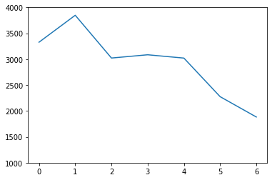

```python
#data.hist('parks_nearest', bins=100, range=(1, 100))
last_weekday = data.groupby('last_weekday').count()['rooms'].reset_index(drop=True)

# Код добавлен после ревью
last_weekday.plot(ylim=(1000, 4000));
last_weekday

#display(data.parks_nearest.mean())
#display(data.parks_nearest.median())
#data['total_area'].value_counts()
```

<div class="alert alert-warning"; style="border-left: 7px solid gold"> **💡 Комментарий ревьюера**

Было бы здорово визуализировать получившийся результат </div>

В изученном наборе данных представлены квартиры общей площадью от 12 до 900 квадратных метров. Основной разброс значений от 18 до 115 метров.

Жилая площадь от 2 до 410 метров. Основной набор значений от 14 до 55 метров.

Размеры кухни от 1,3 до 112 метров. Основной набор значений от 5 до 21 метра.

Количество комнат от 1 до 19. Основной набор значений от 1 до 4 шт.

Высота потолков от 2 до 10 метров. Основной набор значений от 2,5 до 3 метров.

Квартиры продаются с 1 до 33 этажа. Основной набор значений от 1 до 19 этажа. Среднее значение 5,98. Медианное 4.

Примерно 10% квартир на первых и последних этажах.

Всего этажей в домах от 1 до 60. Чаще других от 5-го до 25-го этажей. Среднее значение 10,87. Медианное 9.

Расстояние от центра от 0 до 55 км. Основной набор значений от 0 до 18 км. Среднее значение 14,3. Медианное 13.

Расстояние от аэропорта от 20 до 73 км. Основной набор значений от 20 до 55 км. Среднее значение 28,85. Медианное 26,78.

Расстояние до ближайшего парка от 1 до 3200 м. Основной набор значений от 10 до 1000. Среднее значение 491. Медианное 451.

```
180.7744709964326
```

```
95.0
```

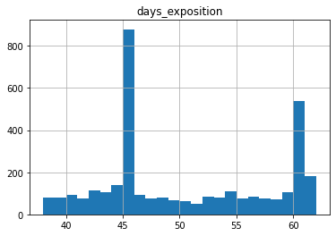

```python
data.hist('days_exposition', bins=24, range=(38, 62))
#data.groupby('rooms')['days_exposition'].mean()
display(data.days_exposition.mean())
display(data.days_exposition.median())
#data['days_exposition'].value_counts()
```

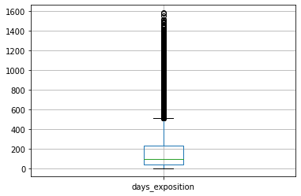

```python
# Код добавлен после ревью
data.boxplot(column='days_exposition');
```

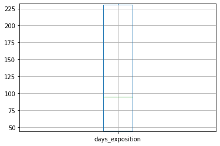

```python
data.boxplot(column='days_exposition')
plt.ylim(44, 232)
plt.show()
```

В данном наборе представлены квартиры которые продавались от 1 дня до 4,5 лет. Очень заметны всплески на 45 и 60 дней. Возможно это связано с периодом размещения объявления. Период продажи от 44 до 232 считается нормальным. До 44 дней очень быстрым. Более 232 дней очень долгим.

<div class="alert alert-warning"; style="border-left: 7px solid gold"> **💡 Комментарий ревьюера**

Ящик с усами удобен тем, что показывает сразу несколько статистик о данных, в том числе выбросы, не только медиану. Поэтому лучше делать его в 2 шага в данном случае: сначала без ограничений по оси, а уже потом с параметром ylim.

Еще рекомендую для графиков делать заголовки и подписи к осям

</div>

### Проведите исследовательский анализ данных

Создание массива с числовыми значениями и матрицы корреляции по ним

```python
# Датафрэйм с числовыми значениями:
# Код изменён после ревью
num_data = data[['total_images', 'last_price', 'total_area', 'ceiling_height', 'floors_total', 'living_area', 'floor', 'kitchen_area', 'days_exposition', 'price_per_meter']]

print(num_data.corr())
```

```
                 total_images  last_price  total_area  ceiling_height  \
total_images         1.000000    0.094950    0.106067        0.044888
last_price           0.094950    1.000000    0.643286        0.253835
total_area           0.106067    0.643286    1.000000        0.357582
ceiling_height       0.044888    0.253835    0.357582        1.000000
floors_total         0.005736   -0.004974   -0.070207       -0.075815
living_area          0.092472    0.575940    0.944769        0.340344
floor                0.027366    0.026621   -0.024462       -0.042987
kitchen_area         0.097841    0.470052    0.630073        0.307458
days_exposition     -0.027474    0.080892    0.149541        0.104565
price_per_meter      0.124871    0.736612    0.305011        0.274683

                 floors_total  living_area     floor  kitchen_area  \
total_images         0.005736     0.092472  0.027366      0.097841
last_price          -0.004974     0.575940  0.026621      0.470052
total_area          -0.070207     0.944769 -0.024462      0.630073
ceiling_height      -0.075815     0.340344 -0.042987      0.307458
floors_total         1.000000    -0.157587  0.678978      0.152786
living_area         -0.157587     1.000000 -0.092303      0.462770
floor                0.678978    -0.092303  1.000000      0.127733
kitchen_area         0.152786     0.462770  0.127733      1.000000
days_exposition     -0.052756     0.142976 -0.039475      0.108373
price_per_meter      0.149267     0.233564  0.131566      0.375549

                 days_exposition  price_per_meter
total_images           -0.027474         0.124871
last_price              0.080892         0.736612
total_area              0.149541         0.305011
ceiling_height          0.104565         0.274683
floors_total           -0.052756         0.149267
living_area             0.142976         0.233564
floor                  -0.039475         0.131566
kitchen_area            0.108373         0.375549
days_exposition         1.000000         0.047688
price_per_meter         0.047688         1.000000
```

<div class="alert alert-success"; style="border-left: 7px solid green"> **👍 Комментарий ревьюера**

Можно сделать вот так:

</div>

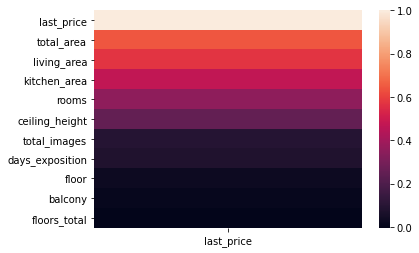

```python
# код ревьюера
import seaborn as sns

for_corr = data[['last_price', 'total_images', 'total_area', 'rooms', 'ceiling_height', 'floors_total', 'living_area', 'floor', 'kitchen_area', 'balcony', 'days_exposition']]
sns.heatmap(for_corr.corr()[['last_price']].sort_values('last_price', ascending=False));
```

<div class="alert alert-danger"; style="border-left: 7px solid red"> **❌ Комментарий ревьюера**

Еще важно разделять тип данных: как удобно хранить данные и что этот тип означает. День недели записан в численном формате, но по смыслу это категориальные, а не порядковые данные, то есть считать корреляцию с ним нельзя. Потому что если в цене четыре вдвое больше двух, а два вдвое больше одного, то для дней недели эта логика не работает </div>

**Мои комментарии:** Деление данных на Категориальные и Числовые часто кажется условным. Например, Этаж или Количество этажей, Количество балконов, Количество комнат, Количество фотографий. Стоит ли их брать в корреляцию? Данные нужно разделять прямо на разные датафрэймы, или речь ижёт об осознанном разделении для аналитика? Подскажите как можно отфильтровать данные одной командой. Пандас или Питон наверняка это умеют, например метод discribe() по умолчанию выводит только числовые.

<div class="alert alert-success"; style="border-left: 7px solid green"> **👍 Комментарий ревьюера 2**

Тут нужно подумать самой и оценить, о каких данных идет речь.

Попробую расписать свой пример подробнее. Если упростить, корреляцию можно трактовать так: чем больше переменная x, тем больше переменная y. Чем больше площадь квартиры, тем больше цена. Чем больше в квартире балконов, тем выше цена. Единицы измерения понятны: считаем цену в рублях, площадь в квадратных метрах, балконы – в балконах. Если корреляция равна единице, то при увеличении балконов вдвое цена тоже вырастет вдвое. Можем их количество умножить на что-то или суммировать.

А вот в чем мы считаем дни недели? И можно ли понедельник умножить на два, чтобы получить вторник? А если субботу разделить на 3?

[figure not shown]

</div>

**Анализ цены:**

Как видно из матрицы корреляции цена на квартиру зависит от её площади. Есть небольшая зависимость от числа комнат, этот параметр явно тесно связан с площадью. Другие зависимости очень слабые.

Посмотрим для наглядности диаграмму рассеивания этих параметров

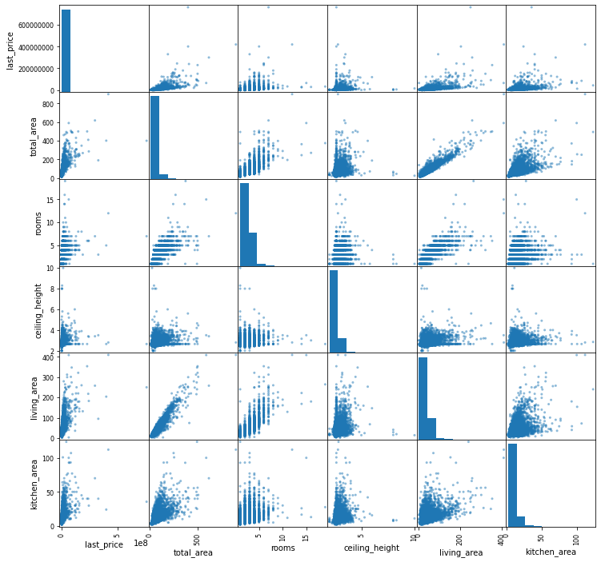

```python
price_addictions = data[['last_price', 'total_area', 'rooms', 'ceiling_height','living_area','kitchen_area']]

pd.plotting.scatter_matrix(price_addictions, figsize=(12, 12))
plt.show()
```

Обзор зависимостей от даты и этажа.

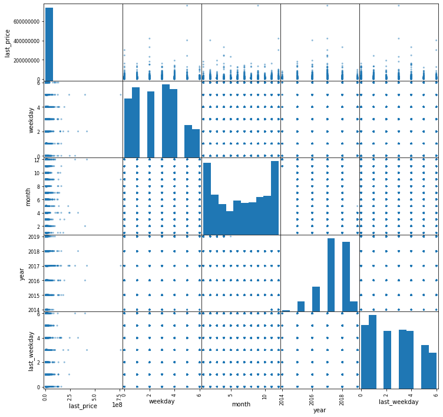

```python
pd.plotting.scatter_matrix(data[['last_price', 'weekday', 'month', 'year', 'last_weekday']], figsize=(12, 12))
plt.show()
```

Средняя цена квартиры в зависимости от категории этажа, на котором она расположена.

```python
#data.groupby('floors_group')['floor'].mean()
floors_group = data.pivot_table(index = ['floors_group'], values = 'last_price', aggfunc = ['mean'])
floors_group.columns = ['mean_price']
floors_group
```

| floors_group | mean_price |
| --- | --- |
| другой | 6.420798e+06 |
| первый | 4.508579e+06 |
| последний | 6.946964e+06 |

Рассмотрим среднюю цену квадратного метра в десяти наиболее крупных населённых пунктах по количеству объявлений.

```python
#data.groupby('locality_name')['locality_name'].count()
great_locality = data.pivot_table(index = ['locality_name'], values = 'price_per_meter', aggfunc = ['count', 'mean'])
great_locality.columns = ['ad_count', 'meter_mean']
great_locality = great_locality.reset_index(drop=False)
great_locality.sort_values(by='ad_count', ascending=False).head(10)
```

|  | locality_name | ad_count | meter_mean |
| --- | --- | --- | --- |
| 207 | Санкт-Петербург | 13632 | 112421.718514 |
| 138 | Мурино | 551 | 85743.233293 |
| 100 | Кудрово | 441 | 94408.041602 |
| 274 | Шушары | 408 | 78010.167480 |
| 33 | Всеволожск | 339 | 68570.615292 |
| 86 | Колпино | 308 | 74865.364347 |
| 188 | Пушкин | 307 | 102074.629153 |
| 158 | Парголово | 302 | 89505.043917 |
| 41 | Гатчина | 268 | 67928.326990 |
| 34 | Выборг | 208 | 57084.582948 |

<div class="alert alert-success"; style="border-left: 7px solid green"> **👍 Комментарий ревьюера**

Еще было бы здорово визуализировать получившиеся таблицы. Например, вот так:

</div>

**Мои комментарии:** Считаю именно тут выводить график это лишнее. Краткая таблица тут вполне достаточна. Тут хочется избавиться от знаков после запятой. astype не работает. Подскажи пожалуйста как лучше представить данные на выводе? И ещё, если можно, сдвиг разрядов, например так: "99 999". Большое спасибо за пример хорошего оформления графика, моих знаний пока не достаточно.

<div class="alert alert-success"; style="border-left: 7px solid green"> **👍 Комментарий ревьюера 2**

Для округления можно использовать `round()` </div>

```python
# код ревьюера

great_locality['meter_mean'] = round(great_locality['meter_mean']).astype(int)
great_locality.sort_values(by='ad_count', ascending=False).head(10)
```

|  | locality_name | ad_count | meter_mean |
| --- | --- | --- | --- |
| 207 | Санкт-Петербург | 13632 | 112422 |
| 138 | Мурино | 551 | 85743 |
| 100 | Кудрово | 441 | 94408 |
| 274 | Шушары | 408 | 78010 |
| 33 | Всеволожск | 339 | 68571 |
| 86 | Колпино | 308 | 74865 |
| 188 | Пушкин | 307 | 102075 |
| 158 | Парголово | 302 | 89505 |
| 41 | Гатчина | 268 | 67928 |
| 34 | Выборг | 208 | 57085 |

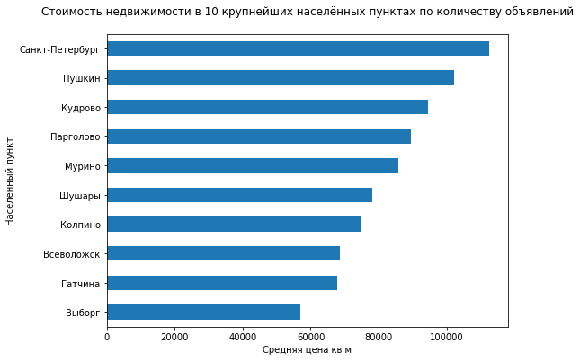

```python
# код ревьюера
locality_plot = great_locality.sort_values(by='ad_count').tail(10)
locality_plot.sort_values(by='meter_mean').plot(x='locality_name', y='meter_mean', kind='barh', figsize=(8,6), legend=False)
plt.xlabel('Средняя цена кв м')
plt.ylabel('Населенный пункт')
plt.title('Стоимость недвижимости в 10 крупнейших населённых пунктах по количеству объявлений\n')
plt.show()
```

Рассмотрим медианную цену квартиры в населённых пунктах. И выведем населённые пункты с наиболее доступным и наиболее дорогим жильём.

```python
locality_price = data.pivot_table(index = ['locality_name'], values = 'last_price', aggfunc = ['count', 'median'])
locality_price.columns = ['ad_count', 'price']
locality_price = locality_price.reset_index(drop=False)
locality_price.sort_values(by='price', ascending=False)
```

|  | locality_name | ad_count | price |
| --- | --- | --- | --- |
| 269 | Хязельки | 1 | 11000000.0 |
| 16 | Бор | 2 | 10397600.0 |
| 1 | Александровская | 2 | 8725000.0 |
| 207 | Санкт-Петербург | 13632 | 5300000.0 |
| 221 | Сестрорецк | 163 | 5250000.0 |
| ... | ... | ... | ... |
| 36 | Выскатка | 2 | 585000.0 |
| 212 | Свирь | 2 | 575000.0 |
| 226 | Совхозный | 2 | 517500.0 |
| 23 | Вахнова Кара | 1 | 450000.0 |
| 234 | Старополье | 3 | 450000.0 |

281 rows × 3 columns

Рассмотрим медианную цену квадратного метра в населённых пунктах. И выведем населённые пункты с наиболее доступным и наиболее дорогим жильём.

```python
median_locality = data.pivot_table(index = ['locality_name'], values = 'price_per_meter', aggfunc = ['count', 'median'])
median_locality.columns = ['ad_count', 'meter_median']
median_locality = median_locality.reset_index(drop=False)
median_locality.sort_values(by='meter_median', ascending=True)
```

|  | locality_name | ad_count | meter_median |
| --- | --- | --- | --- |
| 234 | Старополье | 3 | 11000.000000 |
| 212 | Свирь | 2 | 11481.481481 |
| 23 | Вахнова Кара | 1 | 11688.311688 |
| 36 | Выскатка | 2 | 12335.480902 |
| 226 | Совхозный | 2 | 12629.129129 |
| ... | ... | ... | ... |
| 110 | Левашово | 1 | 96997.690531 |
| 188 | Пушкин | 307 | 97938.144330 |
| 221 | Сестрорецк | 163 | 98341.232227 |
| 62 | Зеленогорск | 21 | 100000.000000 |
| 207 | Санкт-Петербург | 13632 | 103062.645671 |

281 rows × 3 columns

```python
display(data.pivot_table(index = ['locality_name'], values = 'price_per_meter', aggfunc = 'max').sort_values(by='price_per_meter', ascending=False).head(1))

display(data.pivot_table(index = ['locality_name'], values = 'price_per_meter', aggfunc = 'min').sort_values(by='price_per_meter', ascending=False).head(1))
```

| locality_name | price_per_meter |
| --- | --- |
| Санкт-Петербург | 1907500.0 |

| locality_name | price_per_meter |
| --- | --- |
| Левашово | 96997.690531 |

Рассмотрим зависимость средней цены квартиры в зависимости от года публикации объявления:

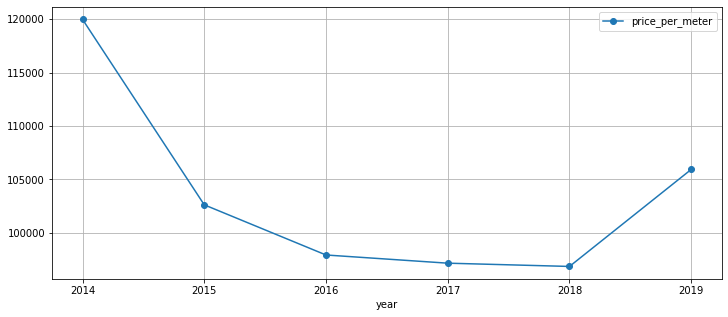

```python
y_data = data.pivot_table(index = ['year'], values = 'price_per_meter', aggfunc = 'mean')

y_data.plot(grid=True, figsize=(12, 5), style='o-')
```

Для Санкт-Петербурга рассмотрим зависимость средней цены метра в зависимости от удалённости от центра:

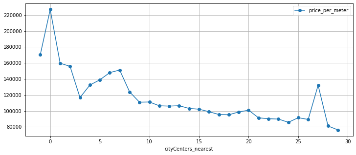

```python
spb_db = data.loc[data['locality_name'] == 'Санкт-Петербург']
spb_distance = spb_db.pivot_table(index = ['cityCenters_nearest'], values = 'price_per_meter', aggfunc = 'mean')
spb_distance.sort_values(by='cityCenters_nearest', ascending=True).plot(grid=True, figsize=(12, 5), style='o-')
```

По графику видно зависимость снижения цены квадратного метра в зависимости от удалённости от центра. На графике присутствуют два пика, которые скорее всего являются случаюностью - выбросом.